# Winter_project

Oxana Kolpakova

06 04 2022

Load the necessary libraries.

Import data file

```r
micedata <- read.csv ("C:/Users/1/Desktop/Data_Cortex_Nuclear.csv", sep =";", header = T, na.strings = c(" ", "NA"))
```

Data correction.

1. Data description.

-72 mice were used in the experiment. -The data contains: expression level of 77 proteins, 2 Genotypes, 2 Treatments, 2 Behavior, 8 class. -The class data is balanced. -Data for 23 proteins are complete without NA, for 5 proteins about 15% is lost, for the rest about 5% is lost

```r
str(micedata)
```

```
## 'data.frame':    1080 obs. of  82 variables:
##  $ MouseID        : chr  "309_1" "309_2" "309_3" "309_4" ...
##  $ DYRK1A_N       : num  0.504 0.515 0.509 0.442 0.435 ...
##  $ ITSN1_N        : num  0.747 0.689 0.73 0.617 0.617 ...
##  $ BDNF_N         : num  0.43 0.412 0.418 0.359 0.359 ...
##  $ NR1_N          : num  2.82 2.79 2.69 2.47 2.37 ...
##  $ NR2A_N         : num  5.99 5.69 5.62 4.98 4.72 ...
##  $ pAKT_N         : num  0.219 0.212 0.209 0.223 0.213 ...
##  $ pBRAF_N        : num  0.178 0.173 0.176 0.176 0.174 ...
##  $ pCAMKII_N      : num  2.37 2.29 2.28 2.15 2.13 ...
##  $ pCREB_N        : num  0.232 0.227 0.23 0.207 0.192 ...
##  $ pELK_N         : num  1.75 1.6 1.56 1.6 1.5 ...
##  $ pERK_N         : num  0.688 0.695 0.677 0.583 0.551 ...
##  $ pJNK_N         : num  0.306 0.299 0.291 0.297 0.287 ...
##  $ PKCA_N         : num  0.403 0.386 0.381 0.377 0.364 ...
```

[output cut: 68 more lines]

```r
skim(micedata)
```

Data summary

| Name | micedata |
| --- | --- |
| Number of rows | 1080 |
| Number of columns | 82 |
| _______________________ |  |
| Column type frequency: |  |
| character | 1 |
| factor | 4 |
| numeric | 77 |
| ________________________ |  |
| Group variables | None |

**Variable type: character**

| skim_variable | n_missing | complete_rate | min | max | empty | n_unique | whitespace |
| --- | --- | --- | --- | --- | --- | --- | --- |
| MouseID | 0 | 1 | 5 | 9 | 0 | 1080 | 0 |

**Variable type: factor**

| skim_variable | n_missing | complete_rate | ordered | n_unique | top_counts |
| --- | --- | --- | --- | --- | --- |
| Genotype | 0 | 1 | FALSE | 2 | Con: 570, Ts6: 510 |
| Treatment | 0 | 1 | FALSE | 2 | Mem: 570, Sal: 510 |
| Behavior | 0 | 1 | FALSE | 2 | S/C: 555, C/S: 525 |
| class | 0 | 1 | FALSE | 8 | c-C: 150, c-S: 150, c-C: 135, c-S: 135 |

**Variable type: numeric**

| skim_variable | n_missing | complete_rate | mean | sd | p0 | p25 | p50 | p75 | p100 | hist |
| --- | --- | --- | --- | --- | --- | --- | --- | --- | --- | --- |
| DYRK1A_N | 3 | 1.00 | 0.43 | 0.25 | 0.15 | 0.29 | 0.37 | 0.49 | 2.52 | ▇▁▁▁▁ |
| ITSN1_N | 3 | 1.00 | 0.62 | 0.25 | 0.25 | 0.47 | 0.57 | 0.70 | 2.60 | ▇▂▁▁▁ |
| BDNF_N | 3 | 1.00 | 0.32 | 0.05 | 0.12 | 0.29 | 0.32 | 0.35 | 0.50 | ▁▂▇▃▁ |
| NR1_N | 7 | 0.99 | 2.30 | 0.35 | 1.33 | 2.06 | 2.30 | 2.53 | 3.76 | ▂▇▇▂▁ |
| NR2A_N | 7 | 0.99 | 3.84 | 0.93 | 1.74 | 3.16 | 3.76 | 4.44 | 8.48 | ▃▇▃▁▁ |
| pAKT_N | 3 | 1.00 | 0.23 | 0.04 | 0.06 | 0.21 | 0.23 | 0.26 | 0.54 | ▁▇▃▁▁ |
| pBRAF_N | 3 | 1.00 | 0.18 | 0.03 | 0.06 | 0.16 | 0.18 | 0.20 | 0.32 | ▁▃▇▁▁ |
| pCAMKII_N | 4 | 1.00 | 3.54 | 1.30 | 1.34 | 2.48 | 3.33 | 4.48 | 7.46 | ▇▇▅▃▁ |
| pCREB_N | 3 | 1.00 | 0.21 | 0.03 | 0.11 | 0.19 | 0.21 | 0.23 | 0.31 | ▁▃▇▅▁ |
| pELK_N | 5 | 1.00 | 1.43 | 0.47 | 0.43 | 1.21 | 1.36 | 1.56 | 6.11 | ▇▂▁▁▁ |
| pERK_N | 3 | 1.00 | 0.55 | 0.35 | 0.15 | 0.34 | 0.44 | 0.66 | 3.57 | ▇▁▁▁▁ |
| pJNK_N | 3 | 1.00 | 0.31 | 0.05 | 0.05 | 0.28 | 0.32 | 0.35 | 0.49 | ▁▁▆▇▁ |
| PKCA_N | 3 | 1.00 | 0.32 | 0.05 | 0.19 | 0.28 | 0.31 | 0.35 | 0.47 | ▂▇▇▃▁ |
| pMEK_N | 3 | 1.00 | 0.28 | 0.05 | 0.06 | 0.24 | 0.28 | 0.30 | 0.46 | ▁▂▇▃▁ |
| pNR1_N | 3 | 1.00 | 0.83 | 0.12 | 0.50 | 0.74 | 0.82 | 0.90 | 1.41 | ▂▇▅▁▁ |
| pNR2A_N | 3 | 1.00 | 0.73 | 0.19 | 0.28 | 0.59 | 0.72 | 0.85 | 1.41 | ▂▇▇▂▁ |
| pNR2B_N | 3 | 1.00 | 1.56 | 0.27 | 0.30 | 1.38 | 1.56 | 1.75 | 2.72 | ▁▂▇▃▁ |
| pPKCAB_N | 5 | 1.00 | 1.53 | 0.48 | 0.57 | 1.17 | 1.37 | 1.89 | 3.06 | ▂▇▃▃▁ |
| pRSK_N | 3 | 1.00 | 0.44 | 0.07 | 0.10 | 0.40 | 0.44 | 0.48 | 0.65 | ▁▁▆▇▁ |
| AKT_N | 3 | 1.00 | 0.68 | 0.13 | 0.06 | 0.60 | 0.68 | 0.76 | 1.18 | ▁▁▇▅▁ |
| BRAF_N | 3 | 1.00 | 0.38 | 0.22 | 0.14 | 0.26 | 0.33 | 0.41 | 2.13 | ▇▁▁▁▁ |
| CAMKII_N | 3 | 1.00 | 0.36 | 0.05 | 0.21 | 0.33 | 0.36 | 0.39 | 0.59 | ▁▇▇▂▁ |
| CREB_N | 3 | 1.00 | 0.18 | 0.03 | 0.11 | 0.16 | 0.18 | 0.20 | 0.32 | ▂▇▃▁▁ |
| ELK_N | 19 | 0.98 | 1.17 | 0.34 | 0.50 | 0.94 | 1.10 | 1.32 | 2.80 | ▅▇▂▁▁ |
| ERK_N | 5 | 1.00 | 2.47 | 0.65 | 1.13 | 1.99 | 2.40 | 2.87 | 5.20 | ▃▇▃▁▁ |
| GSK3B_N | 3 | 1.00 | 1.17 | 0.24 | 0.15 | 1.02 | 1.16 | 1.31 | 2.48 | ▁▅▇▁▁ |
| JNK_N | 3 | 1.00 | 0.24 | 0.03 | 0.05 | 0.22 | 0.24 | 0.26 | 0.39 | ▁▁▇▆▁ |
| MEK_N | 7 | 0.99 | 0.27 | 0.04 | 0.15 | 0.25 | 0.27 | 0.30 | 0.42 | ▁▅▇▃▁ |
| TRKA_N | 3 | 1.00 | 0.69 | 0.12 | 0.20 | 0.62 | 0.70 | 0.77 | 1.00 | ▁▂▅▇▂ |
| RSK_N | 3 | 1.00 | 0.17 | 0.03 | 0.11 | 0.15 | 0.17 | 0.18 | 0.31 | ▃▇▃▁▁ |
| APP_N | 3 | 1.00 | 0.40 | 0.06 | 0.24 | 0.37 | 0.40 | 0.44 | 0.63 | ▂▇▇▂▁ |
| Bcatenin_N | 19 | 0.98 | 2.15 | 0.44 | 1.13 | 1.83 | 2.12 | 2.42 | 3.68 | ▂▇▆▂▁ |
| SOD1_N | 3 | 1.00 | 0.54 | 0.28 | 0.22 | 0.32 | 0.44 | 0.70 | 1.87 | ▇▃▁▁▁ |
| MTOR_N | 3 | 1.00 | 0.45 | 0.07 | 0.20 | 0.41 | 0.45 | 0.49 | 0.68 | ▁▂▇▃▁ |
| P38_N | 3 | 1.00 | 0.42 | 0.09 | 0.23 | 0.35 | 0.41 | 0.47 | 0.93 | ▅▇▂▁▁ |
| pMTOR_N | 4 | 1.00 | 0.76 | 0.12 | 0.17 | 0.68 | 0.76 | 0.84 | 1.12 | ▁▁▆▇▁ |
| DSCR1_N | 3 | 1.00 | 0.59 | 0.10 | 0.16 | 0.53 | 0.58 | 0.63 | 0.92 | ▁▁▇▃▁ |
| AMPKA_N | 3 | 1.00 | 0.37 | 0.06 | 0.23 | 0.33 | 0.36 | 0.40 | 0.70 | ▃▇▂▁▁ |
| NR2B_N | 3 | 1.00 | 0.57 | 0.09 | 0.18 | 0.51 | 0.56 | 0.61 | 0.97 | ▁▂▇▂▁ |
| pNUMB_N | 3 | 1.00 | 0.36 | 0.06 | 0.19 | 0.31 | 0.35 | 0.39 | 0.63 | ▁▇▅▁▁ |
| RAPTOR_N | 3 | 1.00 | 0.32 | 0.05 | 0.19 | 0.28 | 0.30 | 0.35 | 0.53 | ▂▇▃▂▁ |
| TIAM1_N | 3 | 1.00 | 0.42 | 0.07 | 0.24 | 0.37 | 0.41 | 0.46 | 0.72 | ▁▇▅▁▁ |
| pP70S6_N | 3 | 1.00 | 0.39 | 0.16 | 0.13 | 0.28 | 0.38 | 0.48 | 1.13 | ▅▇▂▁▁ |
| NUMB_N | 0 | 1.00 | 0.18 | 0.03 | 0.12 | 0.16 | 0.18 | 0.20 | 0.32 | ▃▇▃▁▁ |
| P70S6_N | 0 | 1.00 | 0.94 | 0.17 | 0.34 | 0.83 | 0.93 | 1.05 | 1.68 | ▁▆▇▂▁ |
| pGSK3B_N | 0 | 1.00 | 0.16 | 0.02 | 0.10 | 0.15 | 0.16 | 0.17 | 0.25 | ▁▇▇▁▁ |
| pPKCG_N | 0 | 1.00 | 1.71 | 0.58 | 0.60 | 1.30 | 1.66 | 2.11 | 3.38 | ▅▇▇▃▁ |
| CDK5_N | 0 | 1.00 | 0.29 | 0.04 | 0.18 | 0.27 | 0.29 | 0.31 | 0.82 | ▇▃▁▁▁ |
| S6_N | 0 | 1.00 | 0.43 | 0.14 | 0.13 | 0.32 | 0.40 | 0.53 | 0.82 | ▂▇▅▃▁ |
| ADARB1_N | 0 | 1.00 | 1.20 | 0.36 | 0.53 | 0.93 | 1.13 | 1.38 | 2.54 | ▅▇▃▁▁ |
| AcetylH3K9_N | 0 | 1.00 | 0.22 | 0.19 | 0.05 | 0.10 | 0.15 | 0.27 | 1.46 | ▇▁▁▁▁ |
| RRP1_N | 0 | 1.00 | 0.17 | 0.03 | -0.06 | 0.15 | 0.16 | 0.18 | 0.61 | ▁▇▁▁▁ |
| BAX_N | 0 | 1.00 | 0.18 | 0.02 | 0.07 | 0.17 | 0.18 | 0.19 | 0.24 | ▁▁▅▇▁ |
| ARC_N | 0 | 1.00 | 0.12 | 0.01 | 0.07 | 0.11 | 0.12 | 0.13 | 0.16 | ▁▂▇▇▂ |
| ERBB4_N | 0 | 1.00 | 0.16 | 0.02 | 0.10 | 0.15 | 0.16 | 0.17 | 0.21 | ▁▂▇▃▁ |
| nNOS_N | 0 | 1.00 | 0.18 | 0.02 | 0.10 | 0.17 | 0.18 | 0.20 | 0.26 | ▁▃▇▅▁ |
| Tau_N | 0 | 1.00 | 0.21 | 0.07 | 0.10 | 0.17 | 0.19 | 0.23 | 0.60 | ▇▅▁▁▁ |
| GFAP_N | 0 | 1.00 | 0.12 | 0.01 | 0.09 | 0.11 | 0.12 | 0.13 | 0.21 | ▂▇▁▁▁ |
| GluR3_N | 0 | 1.00 | 0.22 | 0.03 | 0.11 | 0.20 | 0.22 | 0.25 | 0.33 | ▁▅▇▅▁ |
| GluR4_N | 0 | 1.00 | 0.13 | 0.03 | 0.07 | 0.11 | 0.12 | 0.14 | 0.54 | ▇▁▁▁▁ |
| IL1B_N | 0 | 1.00 | 0.53 | 0.08 | 0.28 | 0.48 | 0.53 | 0.58 | 0.89 | ▁▇▇▁▁ |
| P3525_N | 0 | 1.00 | 0.29 | 0.03 | 0.21 | 0.27 | 0.29 | 0.31 | 0.44 | ▂▇▅▁▁ |
| pCASP9_N | 2 | 1.00 | 1.55 | 0.25 | 0.85 | 1.38 | 1.52 | 1.71 | 2.59 | ▁▇▆▂▁ |
| PSD95_N | 1 | 1.00 | 2.23 | 0.25 | 1.21 | 2.08 | 2.24 | 2.42 | 2.88 | ▁▁▆▇▂ |
| SNCA_N | 0 | 1.00 | 0.16 | 0.02 | 0.10 | 0.14 | 0.16 | 0.17 | 0.26 | ▂▇▅▁▁ |
| Ubiquitin_N | 2 | 1.00 | 1.24 | 0.17 | 0.75 | 1.12 | 1.24 | 1.36 | 1.90 | ▂▇▇▂▁ |
| pGSK3B_Tyr216_N | 1 | 1.00 | 0.85 | 0.09 | 0.58 | 0.79 | 0.85 | 0.92 | 1.20 | ▁▅▇▂▁ |
| SHH_N | 0 | 1.00 | 0.23 | 0.03 | 0.16 | 0.21 | 0.22 | 0.24 | 0.36 | ▂▇▃▁▁ |
| BAD_N | 213 | 0.80 | 0.16 | 0.03 | 0.09 | 0.14 | 0.15 | 0.17 | 0.28 | ▂▇▃▁▁ |
| BCL2_N | 285 | 0.74 | 0.13 | 0.03 | 0.08 | 0.12 | 0.13 | 0.15 | 0.26 | ▅▇▂▁▁ |
| pS6_N | 0 | 1.00 | 0.12 | 0.01 | 0.07 | 0.11 | 0.12 | 0.13 | 0.16 | ▁▂▇▇▂ |
| pCFOS_N | 75 | 0.93 | 0.13 | 0.02 | 0.09 | 0.11 | 0.13 | 0.14 | 0.26 | ▆▇▂▁▁ |
| SYP_N | 0 | 1.00 | 0.45 | 0.07 | 0.26 | 0.40 | 0.45 | 0.49 | 0.76 | ▂▇▇▁▁ |
| H3AcK18_N | 180 | 0.83 | 0.17 | 0.06 | 0.08 | 0.13 | 0.16 | 0.20 | 0.48 | ▇▆▁▁▁ |
| EGR1_N | 210 | 0.81 | 0.18 | 0.04 | 0.11 | 0.16 | 0.17 | 0.20 | 0.36 | ▅▇▃▁▁ |
| H3MeK4_N | 270 | 0.75 | 0.21 | 0.06 | 0.10 | 0.17 | 0.19 | 0.24 | 0.41 | ▅▇▃▁▁ |
| CaNA_N | 1 | 1.00 | 1.34 | 0.32 | 0.59 | 1.08 | 1.32 | 1.59 | 2.13 | ▂▇▇▆▂ |

```r
#  balance  of class
prop.table(table(micedata$class))
```

```
##
##     c-CS-m     c-CS-s     c-SC-m     c-SC-s     t-CS-m     t-CS-s     t-SC-m
## 0.13888889 0.12500000 0.13888889 0.12500000 0.12500000 0.09722222 0.12500000
##     t-SC-s
## 0.12500000
```

2. Are there differences in the level of BDNF_N production depending on the class in the experiment? ANOVA analysis of variance showed that the expression level of BDNF_N was class dependent, p-value < 0.001. With the help of the TukeyHSD test, we found out which classes there are differences between. Effect Size eta-Squared = 0.110 The expression level of BDNF_N differs significantly for the classes: c-SC-m vs. c-CS-m c-SC-m vs. c-CS-s t-SC-s vs. -c-SC-m t-CS-s vs. c-CS-s t-CS-s vs. c-CS-m t-SC-m vs. c-SC-m t-CS-m vs. c-CS-s c-SC-s vs. c-CS-s t-CS-m vs. c-CS-m c-SC-s vs. c-CS-m c-SC-s vs. c-SC-m t-CS-m vs. c-SC-m t-SC-m vs. c-CS-s t-SC-s vs. t-CS-s t-SC-m vs.c-CS-m

```r
#replece NA to column mean
micedata_NA <- replace(micedata, TRUE, lapply(micedata, na.aggregate))
fit <- aov(BDNF_N ~ class, data=micedata_NA)
summary(fit)
```

```
##               Df Sum Sq Mean Sq F value Pr(>F)
## class          7 0.2877 0.04110   18.86 <2e-16 ***
## Residuals   1072 2.3363 0.00218
## ---
## Signif. codes:  0 '***' 0.001 '**' 0.01 '*' 0.05 '.' 0.1 ' ' 1
```

```r
#differences between classes
TukeyHSD(fit)
```

```
##   Tukey multiple comparisons of means
##     95% family-wise confidence level
##
## Fit: aov(formula = BDNF_N ~ class, data = micedata_NA)
##
## $class
##                        diff          lwr           upr     p adj
## c-CS-s-c-CS-m  0.0030979096 -0.013721430  0.0199172491 0.9992917
## c-SC-m-c-CS-m -0.0482716607 -0.064642404 -0.0319009177 0.0000000
## c-SC-s-c-CS-m -0.0258249025 -0.042644242 -0.0090055630 0.0000951
## t-CS-m-c-CS-m -0.0264852092 -0.043304549 -0.0096658697 0.0000539
## t-CS-s-c-CS-m -0.0337569838 -0.051796664 -0.0157173037 0.0000005
## t-SC-m-c-CS-m -0.0181541101 -0.034973450 -0.0013347706 0.0239022
## t-SC-s-c-CS-m -0.0137754256 -0.030594765  0.0030439140 0.2018783
## c-SC-m-c-CS-s -0.0513695703 -0.068188910 -0.0345502307 0.0000000
## c-SC-s-c-CS-s -0.0289228121 -0.046179090 -0.0116665338 0.0000116
## t-CS-m-c-CS-s -0.0295831188 -0.046839397 -0.0123268405 0.0000064
## t-CS-s-c-CS-s -0.0368548934 -0.055302631 -0.0184071559 0.0000001
## t-SC-m-c-CS-s -0.0212520197 -0.038508298 -0.0039957414 0.0047711
## t-SC-s-c-CS-s -0.0168733352 -0.034129613  0.0003829431 0.0606526
## c-SC-s-c-SC-m  0.0224467582  0.005627419  0.0392660977 0.0013979
## t-CS-m-c-SC-m  0.0217864515  0.004967112  0.0386057910 0.0022598
## t-CS-s-c-SC-m  0.0145146769 -0.003525003  0.0325543570 0.2215386
## t-SC-m-c-SC-m  0.0301175506  0.013298211  0.0469368901 0.0000019
## t-SC-s-c-SC-m  0.0344962351  0.017676896  0.0513155747 0.0000000
## t-CS-m-c-SC-s -0.0006603067 -0.017916585  0.0165959716 1.0000000
## t-CS-s-c-SC-s -0.0079320813 -0.026379819  0.0105156562 0.8968036
## t-SC-m-c-SC-s  0.0076707924 -0.009585486  0.0249270707 0.8792780
## t-SC-s-c-SC-s  0.0120494770 -0.005206801  0.0293057552 0.4021715
## t-CS-s-t-CS-m -0.0072717746 -0.025719512  0.0111759629 0.9328398
## t-SC-m-t-CS-m  0.0083310991 -0.008925179  0.0255873773 0.8253357
## t-SC-s-t-CS-m  0.0127097836 -0.004546495  0.0299660619 0.3304773
## t-SC-m-t-CS-s  0.0156028737 -0.002844864  0.0340506111 0.1686513
## t-SC-s-t-CS-s  0.0199815582  0.001533821  0.0384292957 0.0230338
## t-SC-s-t-SC-m  0.0043786846 -0.012877594  0.0216349628 0.9945378
```

```r
#Effect Size eta-Squared = 0.110
etaSquared(fit, anova = TRUE)
```

```
##             eta.sq eta.sq.part       SS   df          MS        F  p
## class     0.109648    0.109648 0.287720    7 0.041102856 18.85974  0
## Residuals 0.890352          NA 2.336313 1072 0.002179397       NA NA
```

```r
means <- tapply(micedata_NA$BDNF_N, micedata_NA$class, mean)
sd <- tapply(micedata_NA$BDNF_N, micedata_NA$class, sd)
class <- c("c-CS-m", "c-CS-s", "c-SC-m", "c-SC-s", "t-CS-m", "t-CS-s", "t-SC-m", "t-SC-s")
plot_data <- data.frame(means, sd, class)

plot_data
```

```
##            means         sd  class
## c-CS-m 0.3392174 0.04688325 c-CS-m
## c-CS-s 0.3423153 0.05488543 c-CS-s
## c-SC-m 0.2909458 0.03858719 c-SC-m
## c-SC-s 0.3133925 0.04363735 c-SC-s
## t-CS-m 0.3127322 0.05117537 t-CS-m
## t-CS-s 0.3054604 0.04334970 t-CS-s
## t-SC-m 0.3210633 0.03321600 t-SC-m
## t-SC-s 0.3254420 0.05690437 t-SC-s
```

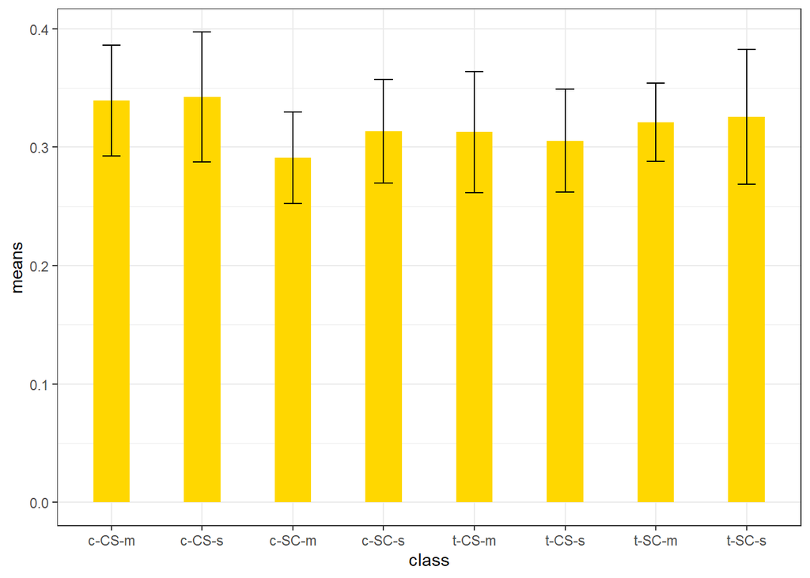

```r
ggplot(plot_data, aes(x=class, y=means)) +
    geom_bar(stat="identity", width=.4, fill="gold") +
    geom_errorbar(aes(ymin=means-sd, ymax=means+sd), width=.2) +
    theme_bw()
```

3. Build a linear model for predicting of the ERBB4_N expression level based on data on other proteins in the experiment.

Prepare data for lm analysis

```r
#Prepare data for analysis

#Remove columns non containing protein levels and convert to matrix.
proteins <- as.matrix(micedata[,c(-1, -79:-82)])

# z-score data
proteins.norm <- apply(proteins, 2, function(x){
  (x-mean(x, na.rm = T))/diff(range(x, na.rm = T))})

# Substitute NAs with mean values
proteins.norm <- apply(proteins.norm, 2, function(x){
  x[is.na(x)] <- mean(x, na.rm = TRUE)
  x
  })

#Divide data into training and test samples.

set.seed(101)
# create a vector with randomly selected observation numbers
tr.index = sample(1:nrow(proteins.norm), nrow(proteins.norm)*0.8)

#form a training sample,80%
trSet = proteins.norm[tr.index, ]
#form a control sample, 20%
testSet = proteins.norm[-tr.index, ]

trSet1 <- as.data.frame(trSet, row.names = NULL, optional = FALSE)
testSet1 <- as.data.frame(testSet, row.names = NULL, optional = FALSE)
```

Make a linear model that predicts the ERBB4_N expression level by all available predictors, Adjusted R-squared=0.8028873, the model is not bad. This is also visible on the plots.

```r
model <- lm(ERBB4_N ~ ., data=trSet1)
#summmary(model)
summary(model)
```

```
##
## Call:
## lm(formula = ERBB4_N ~ ., data = trSet1)
##
## Residuals:
##      Min       1Q   Median       3Q      Max
## -0.22590 -0.03502 -0.00168  0.03465  0.35631
##
## Coefficients: (1 not defined because of singularities)
##                  Estimate Std. Error t value Pr(>|t|)
## (Intercept)     -0.001064   0.002108  -0.505 0.613910
## DYRK1A_N        -0.098780   0.134799  -0.733 0.463901
## ITSN1_N          0.263989   0.154347   1.710 0.087594 .
## BDNF_N          -0.008833   0.055697  -0.159 0.874031
## NR1_N           -0.184631   0.087095  -2.120 0.034328 *
## NR2A_N           0.022542   0.067002   0.336 0.736625
## pAKT_N           0.120846   0.086822   1.392 0.164351
## pBRAF_N         -0.098089   0.058314  -1.682 0.092946 .
## pCAMKII_N       -0.024317   0.029458  -0.825 0.409352
## pCREB_N         -0.075753   0.040250  -1.882 0.060194 .
## pELK_N          -0.052539   0.053799  -0.977 0.329081
## pERK_N          -0.086469   0.178037  -0.486 0.627329
## pJNK_N          -0.175786   0.074636  -2.355 0.018755 *
## PKCA_N           0.125213   0.045423   2.757 0.005975 **
## pMEK_N          -0.032301   0.067563  -0.478 0.632715
## pNR1_N          -0.187408   0.080598  -2.325 0.020314 *
## pNR2A_N          0.062802   0.055415   1.133 0.257432
## pNR2B_N          0.095416   0.100261   0.952 0.341553
## pPKCAB_N         0.060316   0.049870   1.209 0.226850
## pRSK_N           0.067538   0.052174   1.294 0.195882
## AKT_N            0.088823   0.072419   1.227 0.220370
## BRAF_N          -0.248565   0.163666  -1.519 0.129230
## CAMKII_N         0.025781   0.052345   0.493 0.622497
## CREB_N          -0.032831   0.043238  -0.759 0.447885
## ELK_N            0.034953   0.063701   0.549 0.583366
## ERK_N            0.126519   0.071231   1.776 0.076089 .
## GSK3B_N          0.078568   0.107248   0.733 0.464033
## JNK_N            0.007883   0.076141   0.104 0.917568
## MEK_N            0.042456   0.041991   1.011 0.312287
## TRKA_N           0.145118   0.077597   1.870 0.061833 .
```

[output cut: 38 more lines]

```
## BAD_N           -0.086735   0.033060  -2.624 0.008869 **
## BCL2_N          -0.030194   0.029373  -1.028 0.304288
## pS6_N                  NA         NA      NA       NA
## pCFOS_N         -0.063682   0.029882  -2.131 0.033389 *
## SYP_N            0.111294   0.033658   3.307 0.000987 ***
## H3AcK18_N        0.016903   0.030100   0.562 0.574567
## EGR1_N           0.066569   0.029908   2.226 0.026311 *
## H3MeK4_N         0.036763   0.032182   1.142 0.253658
## CaNA_N          -0.113120   0.039259  -2.881 0.004067 **
## ---
## Signif. codes:  0 '***' 0.001 '**' 0.01 '*' 0.05 '.' 0.1 ' ' 1
##
## Residual standard error: 0.0613 on 788 degrees of freedom
## Multiple R-squared:   0.82,  Adjusted R-squared:  0.8029
## F-statistic: 47.87 on 75 and 788 DF,  p-value: < 2.2e-16
```

```r
summary(model)$adj.r.squared
```

```
## [1] 0.8028873
```

```r
result <- predict(model, newdata = testSet1)
result
```

```
##             1             2             3             4             5
## -0.1904887740 -0.2482599489 -0.3480565797 -0.2809811112  0.2491429319
##             6             7             8             9            10
##  0.2105101724  0.1973311124  0.1248287825  0.2677641319  0.2318539812
##            11            12            13            14            15
##  0.2084197418  0.1743757454  0.1556296426  0.1734484480  0.1752497752
##            16            17            18            19            20
##  0.1334309943  0.0823347134  0.1046458568 -0.0662224208 -0.1269015465
##            21            22            23            24            25
## -0.0741153116 -0.1540426892 -0.0136867292 -0.0052641739 -0.0338614292
##            26            27            28            29            30
##  0.1893217850  0.2231637495  0.1013945342 -0.0317691919 -0.0856863801
##            31            32            33            34            35
##  0.0621825851 -0.0040020522  0.0042045838  0.0261886633  0.1223836850
##            36            37            38            39            40
##  0.1073293478  0.0450665152  0.1187455431  0.0744917555  0.0896891116
##            41            42            43            44            45
## -0.0570697998  0.0026384152 -0.0186490206 -0.0859693733 -0.0375829234
##            46            47            48            49            50
## -0.0134767854 -0.0050815457  0.1103870830  0.1981938756  0.1764779126
##            51            52            53            54            55
##  0.0007421264  0.0114677031 -0.0675204002  0.0032734315 -0.1580666803
##            56            57            58            59            60
## -0.0812648436 -0.0661398223  0.0326147523  0.0735498946  0.0285427299
##            61            62            63            64            65
##  0.0655608248  0.0714140704  0.0528716002  0.1624564755  0.1587208409
##            66            67            68            69            70
## -0.0683017944 -0.0316144349  0.0077493434 -0.0382197230 -0.0299869373
##            71            72            73            74            75
## -0.1186625277  0.0408624686 -0.1517044006 -0.1599868942 -0.3524999933
##            76            77            78            79            80
## -0.2087681035 -0.1851225132 -0.2193990443 -0.3137652183 -0.3237202134
##            81            82            83            84            85
##  0.2620302900  0.2209274923  0.1130332354  0.0097508660 -0.0125188056
##            86            87            88            89            90
## -0.1724238559 -0.3686481903 -0.2849394648  0.0361316305  0.0974377046
##            91            92            93            94            95
##  0.0486310972  0.0817630258  0.0982283411  0.1220683277  0.0683466929
##            96            97            98            99           100
##  0.0816021404 -0.0781376071 -0.0580635025 -0.0335002560 -0.0517259799
```

[output cut: 33 more lines]

```
##  0.0638420180  0.0011860377  0.0160944088 -0.0451400113  0.0219422797
##           186           187           188           189           190
##  0.0803500375  0.0450300684  0.1030438573  0.0379466698  0.1842734258
##           191           192           193           194           195
##  0.0018534224 -0.0046675927 -0.0208369024 -0.0081275496 -0.0029046223
##           196           197           198           199           200
## -0.0893452012 -0.0666748346 -0.0468205638 -0.0883486870 -0.1586368410
##           201           202           203           204           205
## -0.2279579533 -0.2114624650 -0.1906175729  0.1891636750  0.1647696192
##           206           207           208           209           210
##  0.1446699484  0.1396688683  0.0520505945 -0.0677875777 -0.0547780879
##           211           212           213           214           215
## -0.0552036136  0.0864749255  0.1102777160  0.0293363971  0.0405774993
##           216
##  0.1594945499
```

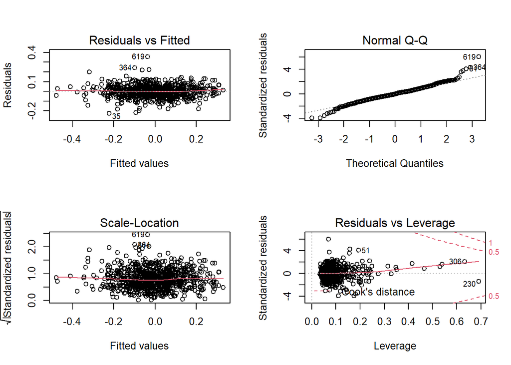

```r
par(mfrow = c(2, 2))
plot(model)
```

4. Run and visualise the result of PCA. 8 PCs explain 78% of variance

```r
pca <- prcomp(proteins.norm)
summary(pca)#  8 PCs explain 78% of variance
```

```
## Importance of components:
##                           PC1    PC2    PC3     PC4    PC5     PC6    PC7
## Standard deviation     0.6189 0.5143 0.3979 0.36066 0.2898 0.25327 0.2480
## Proportion of Variance 0.2522 0.1741 0.1042 0.08563 0.0553 0.04222 0.0405
## Cumulative Proportion  0.2522 0.4263 0.5305 0.61612 0.6714 0.71364 0.7541
##                            PC8     PC9    PC10    PC11    PC12    PC13    PC14
## Standard deviation     0.19295 0.18189 0.16998 0.15801 0.13839 0.13361 0.12458
## Proportion of Variance 0.02451 0.02178 0.01902 0.01643 0.01261 0.01175 0.01022
## Cumulative Proportion  0.77865 0.80043 0.81945 0.83588 0.84849 0.86024 0.87046
##                           PC15    PC16    PC17    PC18    PC19    PC20    PC21
## Standard deviation     0.11915 0.11706 0.10587 0.10452 0.09784 0.09492 0.09299
## Proportion of Variance 0.00935 0.00902 0.00738 0.00719 0.00630 0.00593 0.00569
## Cumulative Proportion  0.87980 0.88882 0.89620 0.90339 0.90969 0.91563 0.92132
##                           PC22    PC23    PC24    PC25    PC26    PC27    PC28
## Standard deviation     0.08774 0.08180 0.07910 0.07843 0.07614 0.07288 0.07069
## Proportion of Variance 0.00507 0.00441 0.00412 0.00405 0.00382 0.00350 0.00329
## Cumulative Proportion  0.92639 0.93079 0.93491 0.93896 0.94278 0.94627 0.94956
##                           PC29    PC30    PC31    PC32    PC33    PC34    PC35
## Standard deviation     0.06743 0.06382 0.06342 0.06154 0.06017 0.05862 0.05643
## Proportion of Variance 0.00299 0.00268 0.00265 0.00249 0.00238 0.00226 0.00210
## Cumulative Proportion  0.95255 0.95524 0.95788 0.96038 0.96276 0.96502 0.96712
##                           PC36    PC37    PC38    PC39    PC40    PC41    PC42
## Standard deviation     0.05537 0.05292 0.05157 0.04904 0.04785 0.04741 0.04562
## Proportion of Variance 0.00202 0.00184 0.00175 0.00158 0.00151 0.00148 0.00137
## Cumulative Proportion  0.96914 0.97098 0.97273 0.97431 0.97582 0.97730 0.97867
##                           PC43    PC44    PC45    PC46    PC47    PC48    PC49
## Standard deviation     0.04502 0.04294 0.04280 0.04181 0.04008 0.03825 0.03784
## Proportion of Variance 0.00133 0.00121 0.00121 0.00115 0.00106 0.00096 0.00094
## Cumulative Proportion  0.98000 0.98122 0.98242 0.98357 0.98463 0.98560 0.98654
##                           PC50    PC51    PC52    PC53    PC54    PC55    PC56
## Standard deviation     0.03730 0.03545 0.03523 0.03417 0.03376 0.03350 0.03212
## Proportion of Variance 0.00092 0.00083 0.00082 0.00077 0.00075 0.00074 0.00068
## Cumulative Proportion  0.98745 0.98828 0.98910 0.98987 0.99062 0.99136 0.99203
##                           PC57    PC58    PC59    PC60    PC61    PC62    PC63
## Standard deviation     0.03181 0.03123 0.03106 0.03033 0.02912 0.02884 0.02732
## Proportion of Variance 0.00067 0.00064 0.00063 0.00061 0.00056 0.00055 0.00049
## Cumulative Proportion  0.99270 0.99334 0.99398 0.99458 0.99514 0.99569 0.99618
##                           PC64    PC65    PC66    PC67    PC68    PC69    PC70
## Standard deviation     0.02720 0.02620 0.02407 0.02379 0.02310 0.02231 0.02124
## Proportion of Variance 0.00049 0.00045 0.00038 0.00037 0.00035 0.00033 0.00030
## Cumulative Proportion  0.99667 0.99712 0.99750 0.99787 0.99822 0.99855 0.99885
##                           PC71    PC72    PC73    PC74    PC75    PC76
## Standard deviation     0.02057 0.01932 0.01907 0.01675 0.01327 0.01150
## Proportion of Variance 0.00028 0.00025 0.00024 0.00018 0.00012 0.00009
## Cumulative Proportion  0.99913 0.99937 0.99961 0.99980 0.99991 1.00000
##                             PC77
## Standard deviation     2.749e-16
## Proportion of Variance 0.000e+00
## Cumulative Proportion  1.000e+00
```

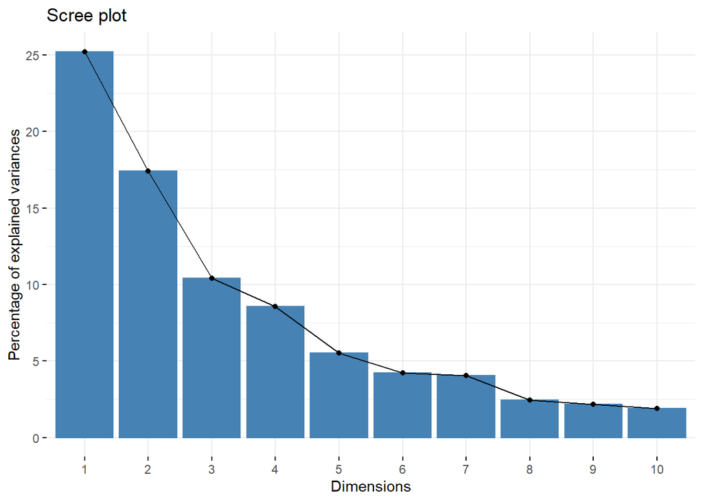

```r
fviz_eig(pca)
```

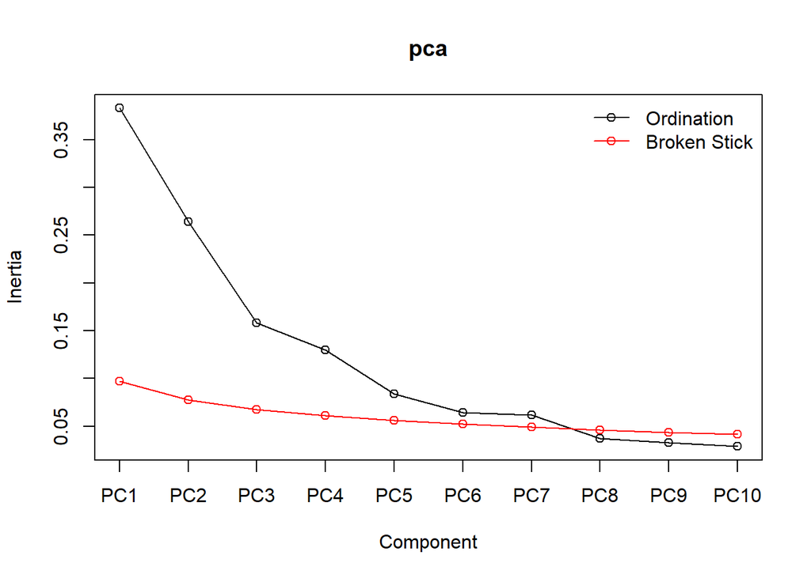

```r
screeplot(pca, type = "lines", bstick = TRUE) # it is necessary to leave 8PCs
```

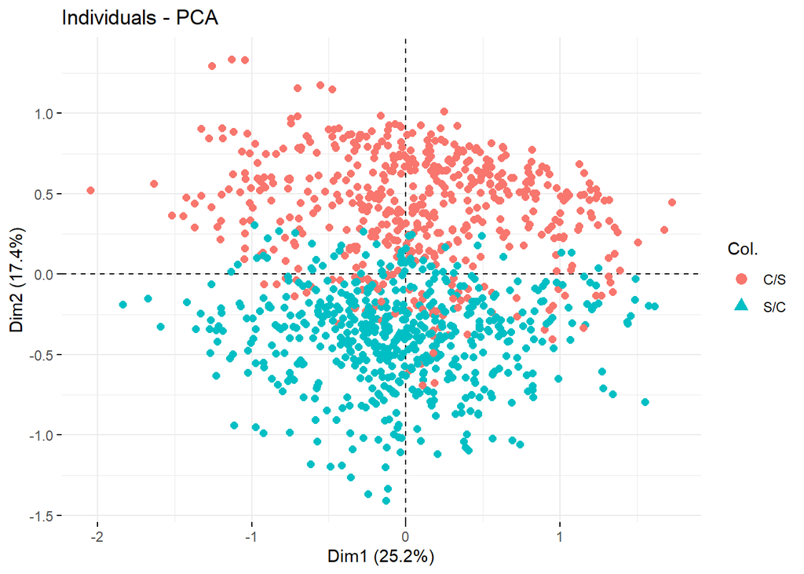

```r
fviz_pca_ind(pca, col.ind = micedata$Behavior, geom = "point", pch = 20) +
  geom_point(size=2, aes(col = micedata$Behavior))
```

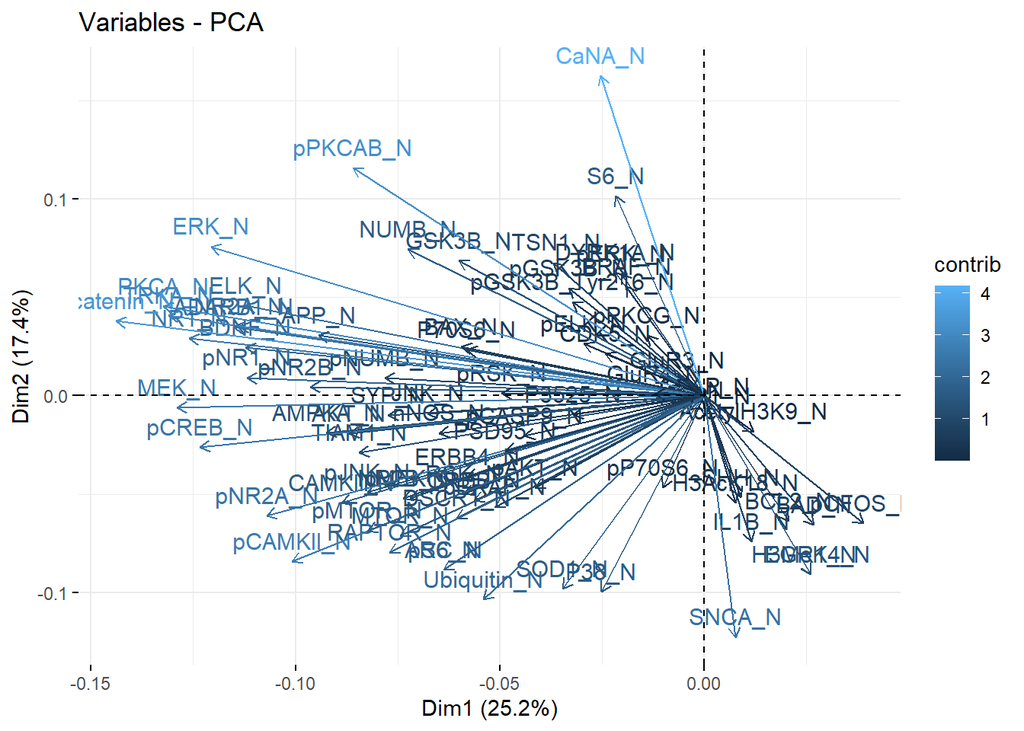

```r
fviz_pca_var(pca, col.var = "contrib")
```